# STAT5243_proj1

Xinyun Li

2022-09-15

## Step 0

#### Import library we needed in analysis

```r
library(tibble)
library(dplyr)
library(tidyr)
library(tidyverse)
library(RColorBrewer)
library(beeswarm)
library(tm)
library(SnowballC)
library(wordcloud)
library(sentimentr)
library(syuzhet)
source("C:/Users/12973/Desktop/STAT5243/Proj 1/lib/function.R")
```

#### Import philosophy dataset

```r
phi_data <- read.csv("C:/Users/12973/Desktop/STAT5243/Proj 1/data/philosophy_data.csv")
summary(phi_data)
```

```
##     title              author             school          sentence_spacy
##  Length:360808      Length:360808      Length:360808      Length:360808
##  Class :character   Class :character   Class :character   Class :character
##  Mode  :character   Mode  :character   Mode  :character   Mode  :character
##
##
##
##  sentence_str       original_publication_date corpus_edition_date
##  Length:360808      Min.   :-350              Min.   :1887
##  Class :character   1st Qu.:1641              1st Qu.:1991
##  Mode  :character   Median :1817              Median :2001
##                     Mean   :1327              Mean   :1995
##                     3rd Qu.:1949              3rd Qu.:2007
##                     Max.   :1985              Max.   :2016
##  sentence_length  sentence_lowered   tokenized_txt      lemmatized_str
##  Min.   :  20.0   Length:360808      Length:360808      Length:360808
##  1st Qu.:  75.0   Class :character   Class :character   Class :character
##  Median : 127.0   Mode  :character   Mode  :character   Mode  :character
##  Mean   : 150.8
##  3rd Qu.: 199.0
##  Max.   :2649.0
```

## STEP 1

#### The data is somehow already cleaned but we are still missing one categorical feature that counts for number of words in sentences. In the dataset, we have sentence length that counts for the number of characters in sentences. However, it is relatively less meaning full that number of words in each sentence. Thus, it is important and we want to include it in our analysis.

```r
phi_data$Words <- count_word(phi_data$tokenized_txt)
#filter meaningless sentences
phi_data <- phi_data%>% filter(Words != 0)
```

## STEP 2

#### First,we looked at the categorical features of our dataset.

#### From the histogram, the capitalism, empiricalism, german idealism and rationalism have higher average sentence length.

```r
phi_byschool <- phi_data %>% group_by(school) %>% summarise(words_ave = mean(Words))
ggplot(phi_byschool, aes(x=school, y=words_ave, fill=words_ave))+
  geom_bar(stat="identity")+
  theme(axis.text.x = element_text(angle = 90, size = 10))
```

[figure not shown]

### Title #### Note that the work “Discourse on Method” have highest sentence length.

```r
phi_bytitle <- phi_data %>% group_by(title) %>% summarise(words_ave = mean(Words))
ggplot(phi_bytitle, aes(x=title, y=words_ave, fill=words_ave)) + geom_bar(stat="identity")+
  theme(axis.text.x = element_text(angle = 90, size = 10))
```

[figure not shown]

#### Philosopher Descartes has highest average sentence length than others, we can guess that might come from his work”Discourse on Methodd”,which has highest averge sentencen length than all other works in our dataset.

```r
phi_byauthor <- phi_data %>% group_by(author) %>% summarise(words_ave = mean(Words))
ggplot(phi_byauthor, aes(x=author, y=words_ave, fill=words_ave)) + geom_bar(stat="identity")+
  theme(axis.text.x = element_text(angle = 90, size = 10))
```

[figure not shown]

#### Top four school with longest average word counts

```r
phi_capt <- phi_data%>%filter(school == "capitalism")
phi_emp <- phi_data%>%filter(school == "empiricism")
phi_rat <- phi_data%>%filter(school == "rationalism")
phi_ger <- phi_data%>% filter(school == "german_idealism")
```

### Capitalism:

```r
phi_capt$OrderedAuthor<- reorder(phi_capt$author,phi_capt$Words,mean,order = T)
levels(phi_capt$OrderedAuthor)
```

```
## [1] "Smith"   "Ricardo" "Keynes"
```

```r
beeswarm(Words~OrderedAuthor,data = phi_capt,horizontal = TRUE,pch=16,
                  cex=0.55, cex.axis=1, cex.lab=1.2,col = alpha(brewer.pal(3,"Set1"),0.6),
                  xlab="Number of words in a sentence.", ylab="",
                  main="Capitalism Author")
```

[figure not shown]

#### Longest Sentences by Smith

```r
phi_capt %>% filter(author == "Smith", Words >= 150)%>%
  select(title,sentence_str)%>% sample_n(4)
```

```
##                   title
## 1 The Wealth Of Nations
## 2 The Wealth Of Nations
## 3 The Wealth Of Nations
## 4 The Wealth Of Nations
##                                                                                                                                                                                                                                                                                                          …
## 1                                                                                                                                                                                                                                                                                       It should as read…
## 2                                                                                                                                                                                                                                                                                                        …
## 3 Were we to examine, in the same manner, all the different parts of his dress and household furniture, the coarse linen shirt which he wears next his skin, the shoes which cover his feet, the bed which he lies on, and all the different parts which compose it, the kitchen grate at which he prepar…
## 4                                                                                                                                                                                                                                                                                                        …
```

### Empiricalism.

#### Locke has longer sentence length in his Empiricalism works, typically most long sentences originate from his work “Second Treatise On Government”

```r
phi_emp$OrderedAuthor<- reorder(phi_emp$author,phi_emp$Words,mean,order = T)
levels(phi_emp$OrderedAuthor)
```

```
## [1] "Berkeley" "Hume"     "Locke"
```

```r
beeswarm(Words~OrderedAuthor,data = phi_emp,horizontal = TRUE,pch=16,
                  cex=0.55, cex.axis=1, cex.lab=1,col = alpha(brewer.pal(3,"Set1"),0.6),
                  xlab="Number of words in a sentence.", ylab="",
                  main="Empiricalism Author")
```

[figure not shown]

#### Longest Sentences by Locke

```r
phi_emp %>% filter(author == "Locke", Words >= 150)%>%
  select(title,sentence_str)%>% sample_n(4)
```

```
##                                  title
## 1        Second Treatise On Government
## 2 Essay Concerning Human Understanding
## 3        Second Treatise On Government
## 4 Essay Concerning Human Understanding
##                                                                                                                                                                                                                                                                                                          …
## 1 And to let us see, that even absolute power, where it is necessary, is not arbitrary by being absolute, but is still limited by that reason, and confined to those ends, which required it in some cases to be absolute, we need look no farther than the common practice of martial discipline: for th…
## 2                                                                                                                                                                                                                                                                                   If it be the motion o…
## 3                                                                                                     Bread, wine and cloth, are things of daily use, and great plenty; yet notwithstanding, acorns, water and leaves, or skins, must be our bread, drink and cloathing, did not labour furnish us with t…
## 4                                                                                                                                                                                                                                                                                                        …
```

### German Idealism

#### Kant has longer sentence length in his German Idealism works, typically most long sentences originate from his work “Critique Of Pure Reason”

```r
phi_ger$OrderedAuthor<- reorder(phi_ger$author,phi_ger$Words,mean,order = T)
levels(phi_ger$OrderedAuthor)
```

```
## [1] "Fichte" "Hegel"  "Kant"
```

```r
beeswarm(Words~OrderedAuthor,data = phi_ger,horizontal = TRUE,pch=16,
                  cex=0.55, cex.axis=1, cex.lab=1,col = alpha(brewer.pal(4,"Set1"),0.6),
                  xlab="Number of words in a sentence.", ylab="",
                  main="Author")
```

[figure not shown]

#### Longest Sentences by Kant

```r
phi_ger %>% filter(author == "Kant", Words >= 150)%>%
  select(title,sentence_str)%>% sample_n(4)
```

```
##                     title
## 1   Critique Of Judgement
## 2 Critique Of Pure Reason
## 3 Critique Of Pure Reason
## 4 Critique Of Pure Reason
##                                                                                                                                                                                                                                                                                                          …
## 1                                                     At present I am not disposed to deal with the ground of this delight, connected, as it is, with a representation in which we would least of all look for it a representation, namely, that lets us see its own inadequacy, and consequently its sub…
## 2 The absolute totality of the series of these conditions in the derivation of their members is an idea which of course can never come about fully in the empirical use of reason, but nevertheless serves as a rule for the way we ought to proceed in regard to them: namely that in the explanation of…
## 3                                                                                                                                                                               And indeed one regards the causality of reason not as a mere concurrence with other causes, but as complete in itself, ev…
## 4                                                                                       The discipline of pure reason in dogmatic use Since we have made it our duty to determine the bounds of pure rea son in transcendental use exactly and with certainty, but this sort of en deavor has the peculia…
```

### Rationalism

#### Descartes has longer sentence length in his Rationalism works, typically most long sentences originate from his work “Discourse On Method”, which mathes our observations before.

```r
phi_rat$OrderedAuthor<- reorder(phi_rat$author,phi_rat$Words,mean,order = T)
levels(phi_rat$OrderedAuthor)
```

```
## [1] "Spinoza"     "Leibniz"     "Malebranche" "Descartes"
```

```r
beeswarm(Words~OrderedAuthor,data = phi_rat,horizontal = TRUE,pch=16,
                  cex=0.55, cex.axis=1, cex.lab=1,col = alpha(brewer.pal(4,"Set1"),0.6),
                  xlab="Number of words in a sentence.", ylab="",
                  main="Author")
```

[figure not shown]

#### Longest Sentences by Descartes

```r
phi_rat %>% filter(author == "Descartes", Words >= 150)%>%
  select(title,sentence_str)%>% sample_n(4)
```

```
##                 title
## 1 Discourse On Method
## 2 Discourse On Method
## 3 Discourse On Method
## 4 Discourse On Method
##                                                                                                                                                                                                                                                                                                          …
## 1                                                                                                                                                                                                                                Of these considerations, the first is, that if I failed to do so, many w…
## 2                                                                                                                                                                                                                    I here entered, in conclusion, upon the subject of the soul at considerable length, …
## 3 And, in the last place, what above all is here worthy of observation, is the generation of the animal spirits, which are like a very subtle wind, or rather a very pure and vivid flame which, continually ascending in great abundance from the heart to the brain, thence penetrates through the nerv…
## 4                                                                                                                                                                                                            Finally, if there be still persons who are not sufficiently persuaded of the existence of Go…
```

# STEP3 Wordcloud

## Wordcloud by schools.

```r
school_list<- as.vector(levels(factor(phi_data$school)))
school_list
```

```
##  [1] "analytic"        "aristotle"       "capitalism"      "communism"
##  [5] "continental"     "empiricism"      "feminism"        "german_idealism"
##  [9] "nietzsche"       "phenomenology"   "plato"           "rationalism"
## [13] "stoicism"
```

```
## [1] "analytic"
##          word freq
## can       can 5057
## say       say 4821
## mean     mean 3638
## case     case 3380
## true     true 3055
## will     will 2835
## use       use 2813
## differ differ 2789
## sens     sens 2786
## world   world 2668
```

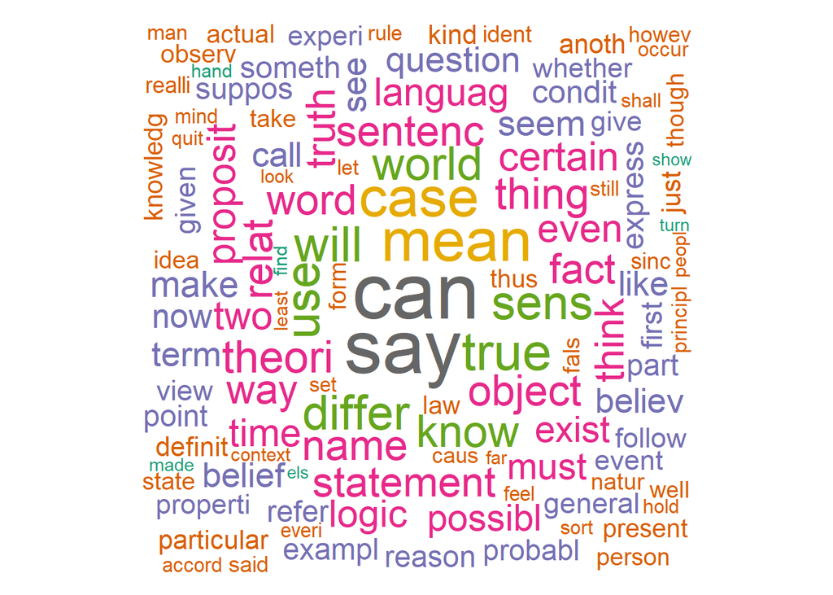

```
## [1] "aristotle"
##        word freq
## thing thing 7366
## will   will 5478
## must   must 4482
## part   part 4139
## man     man 4134
## anim   anim 3853
## natur natur 3479
## case   case 3294
## good   good 2918
## bodi   bodi 2878
```

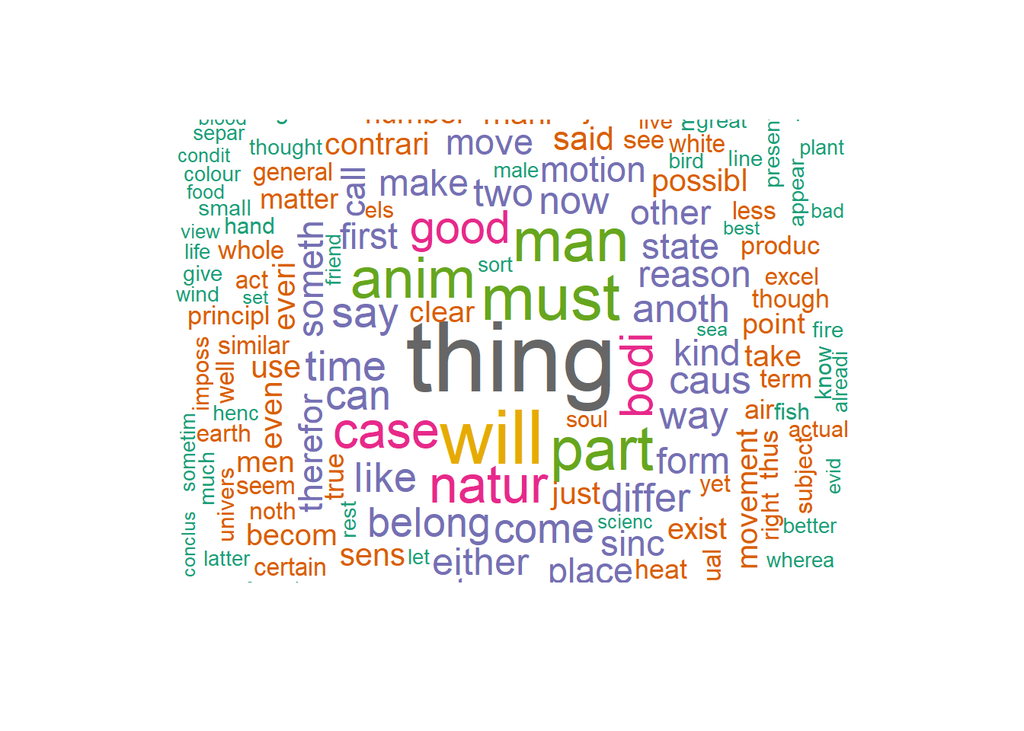

```
## [1] "capitalism"
##            word freq
## price     price 2629
## countri countri 2313
## will       will 2216
## upon       upon 2210
## labour   labour 2198
## employ   employ 2195
## part       part 2054
## produc   produc 1955
## money     money 1903
## great     great 1858
```

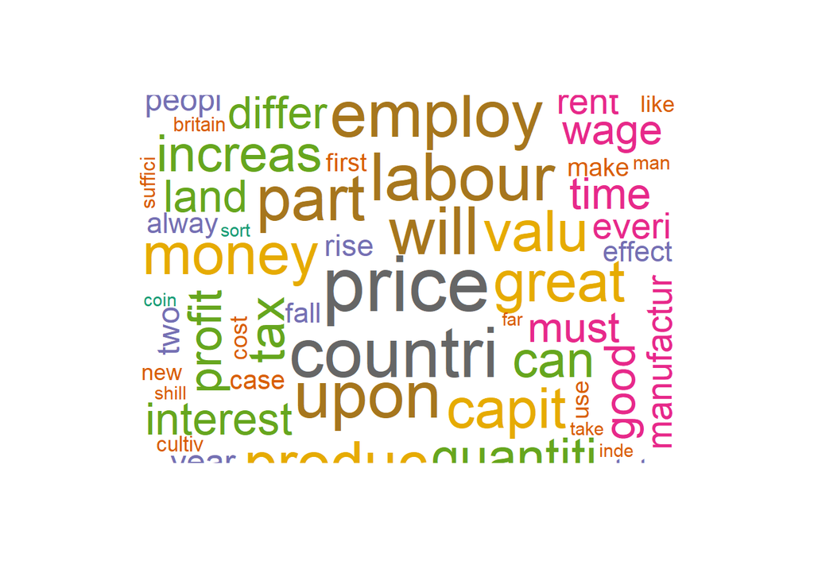

```
## [1] "communism"
##                  word freq
## labour         labour 4321
## valu             valu 2754
## product       product 2467
## work             work 2171
## capit           capit 1844
## commod         commod 1393
## form             form 1266
## power           power 1228
## time             time 1225
## capitalist capitalist 1093
```

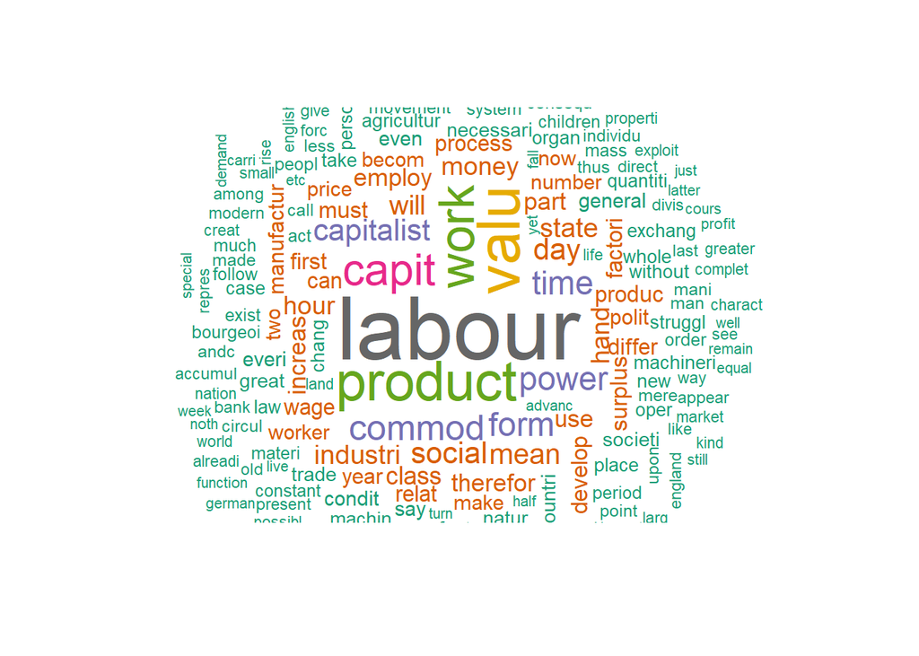

```
## [1] "continental"
##            word freq
## form       form 3173
## mad         mad 2832
## differ   differ 2728
## natur     natur 2106
## can         can 2083
## relat     relat 2037
## languag languag 1816
## time       time 1785
## order     order 1768
## mean       mean 1733
```

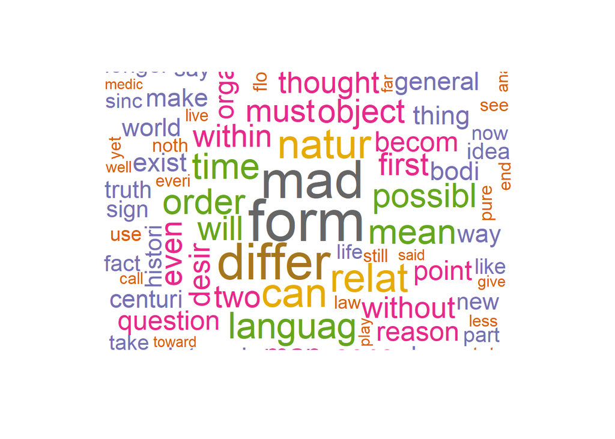

```
## [1] "empiricism"
##          word freq
## idea     idea 5866
## mind     mind 2396
## can       can 2336
## will     will 2255
## natur   natur 2092
## thing   thing 2042
## reason reason 1858
## object object 1848
## make     make 1803
## exist   exist 1611
```

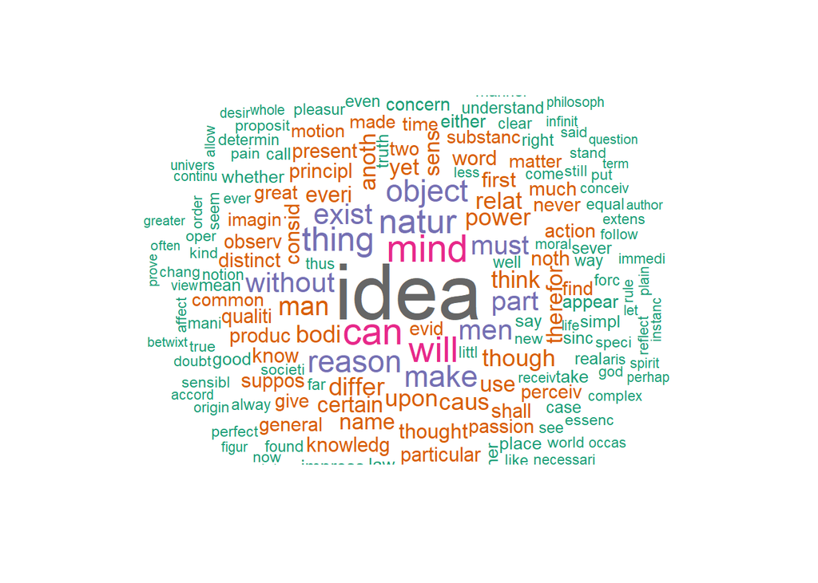

```
## [1] "feminism"
##        word freq
## woman woman 3127
## women women 3064
## man     man 1876
## will   will 1662
## love   love 1237
## men     men 1216
## can     can 1050
## life   life 1003
## like   like  878
## even   even  875
```

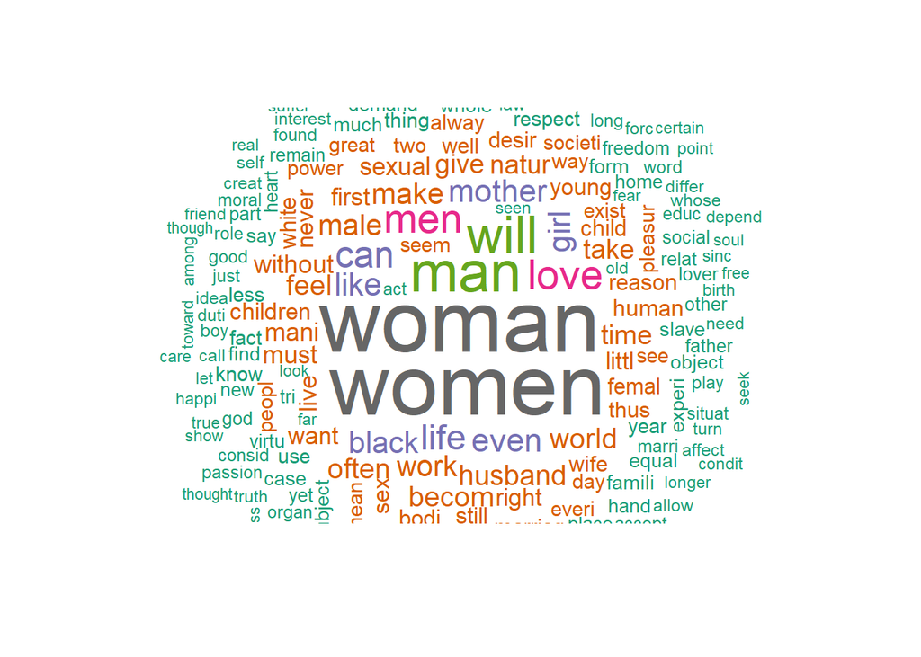

```
## [1] "german_idealism"
##                word freq
## determin   determin 7965
## object       object 5750
## concept     concept 5721
## natur         natur 4550
## can             can 4155
## exist         exist 3804
## self           self 3782
## reason       reason 3767
## conscious conscious 3666
## will           will 3353
```

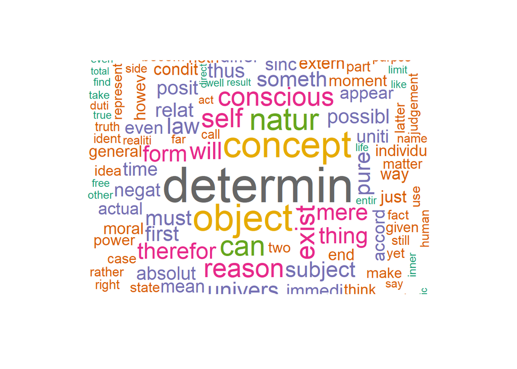

```
## [1] "nietzsche"
##                    word freq
## will               will 1078
## man                 man 1078
## even               even  881
## thou               thou  867
## thing             thing  782
## life               life  680
## god                 god  649
## must               must  633
## zarathustra zarathustra  626
## good               good  593
```

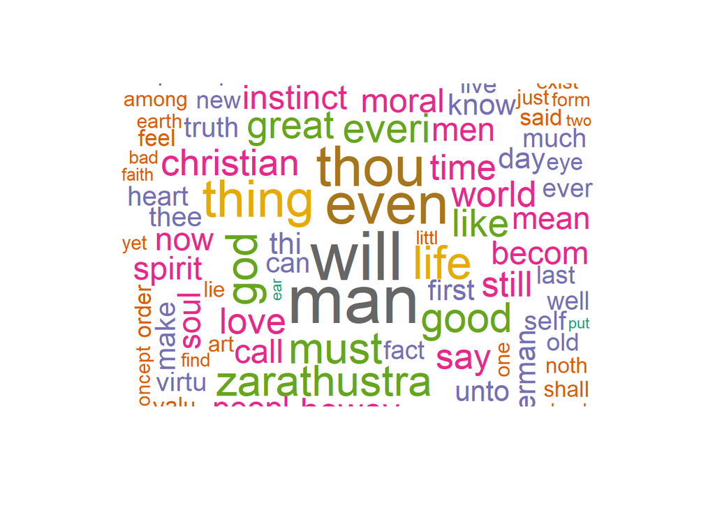

```
## [1] "phenomenology"
##                word freq
## world         world 4463
## object       object 3088
## can             can 2591
## mean           mean 2439
## thing         thing 2299
## way             way 2011
## time           time 1941
## possibl     possibl 1911
## present     present 1882
## conscious conscious 1748
```

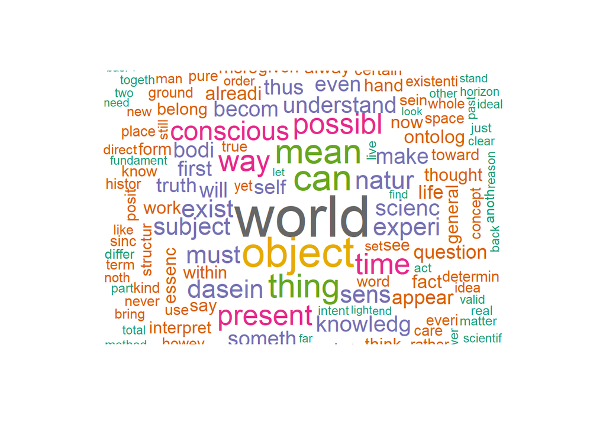

```
## [1] "plato"
##        word freq
## thing thing 4613
## say     say 3573
## will   will 3363
## think think 2460
## now     now 2447
## good   good 2390
## said   said 2331
## must   must 2272
## man     man 2194
## make   make 2142
```

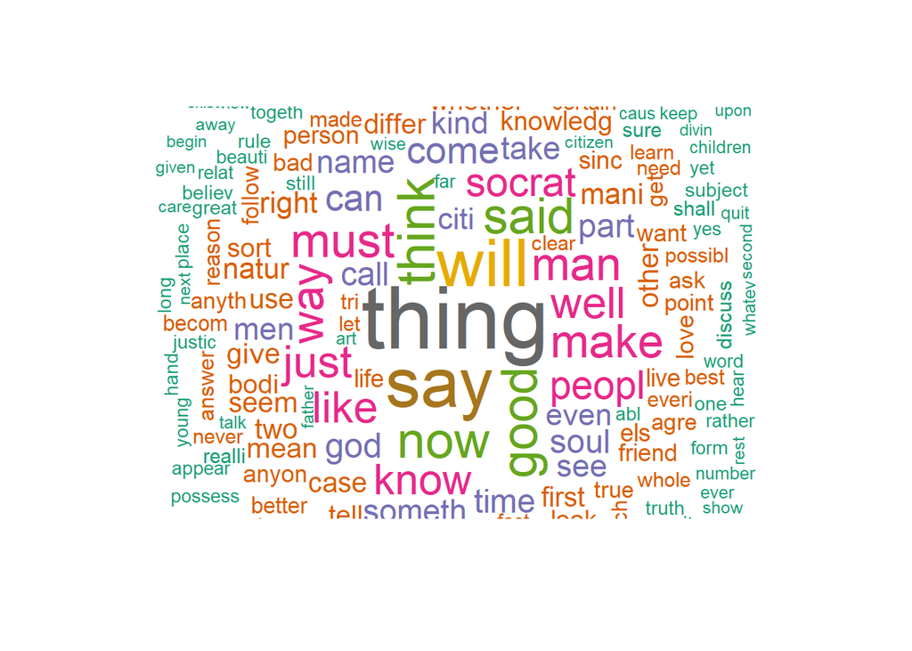

```
## [1] "rationalism"
##          word freq
## god       god 3568
## will     will 3296
## thing   thing 3184
## bodi     bodi 2954
## mind     mind 2574
## can       can 2546
## natur   natur 2287
## idea     idea 2206
## reason reason 1917
## caus     caus 1820
```

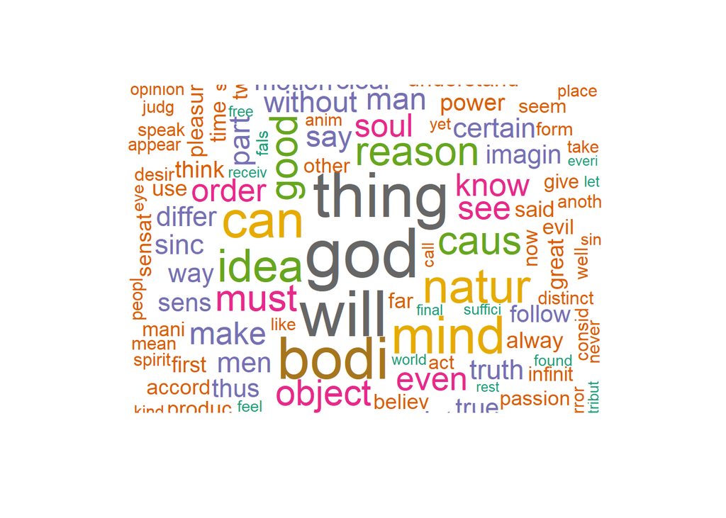

```
## [1] "stoicism"
##          word freq
## thou     thou  798
## thing   thing  687
## unto     unto  436
## natur   natur  370
## man       man  341
## thi       thi  338
## thee     thee  306
## will     will  269
## either either  251
## doth     doth  247
```

[1 more figures not shown]

```r
for (i in 1:length(school_list)){
  school<- phi_data%>%filter(school == school_list[i])
  print(school_list[i])
  text <- school$sentence_lowered
 text <- Corpus(VectorSource(text))
 text <- tm_map(text,removeWords,c("one","may","might","also",stopwords(kind = "en")))
 text <- tm_map(text,removePunctuation)
 text <- tm_map(text,stemDocument)
 dtm <<- TermDocumentMatrix(text)
 m <- as.matrix(dtm)
 v <- sort(rowSums(m),decreasing = TRUE)
 d <- data.frame(word = names(v),freq = v)
 print(head(d,10))
 set.seed(5243)
 wordcloud(text,max.words = 200,random.order =FALSE,colors = brewer.pal(8,"Dark2"))

}
```

## STEP 4 Sentiment analysis by author

[figure not shown]

### What emotion dominate Aristotle, Plato, Marx, Smith and Nietzsche’s work?

#### We can observe from the plots below that Aristotle’s work exuded Anticipation, joy and trust. Also, he reveals some sadness at the same time, this variation possibly result from different work from differetn phase of his life

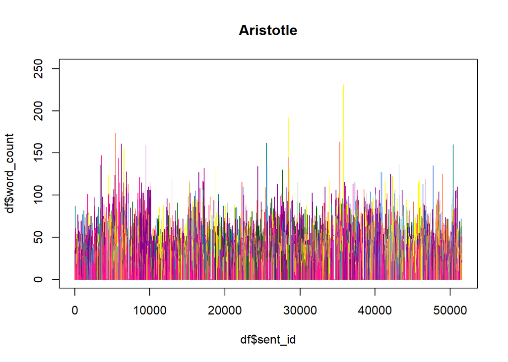

```r
aristotle_data <- get_author(phi_data,"Aristotle")
senti_plot(aristotle_data,"Aristotle")
```

#### Plato’s work are more involving with sadness and disgust.

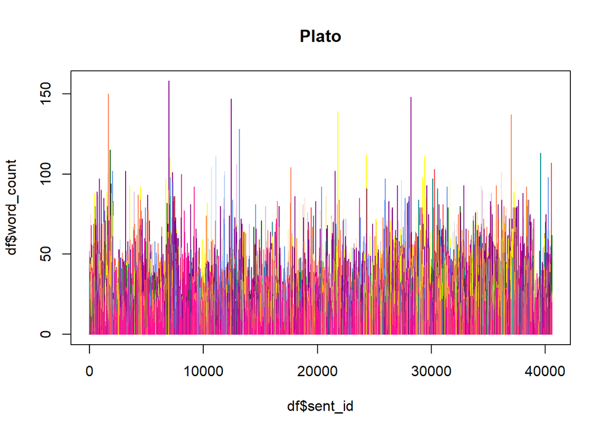

```r
plato_data <- get_author(phi_data,"Plato")
senti_plot(plato_data,"Plato")
```

#### Marx’s works have more emotion of anticipation and anger.

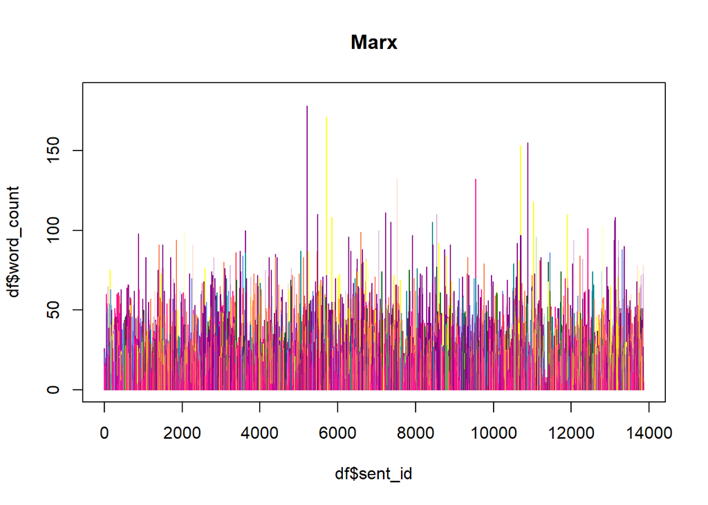

```r
marx_data <- get_author(phi_data,"Marx")
senti_plot(marx_data,"Marx")
```

#### Nietzsche’s work shows much more sadness and fear than philisopher’s above.

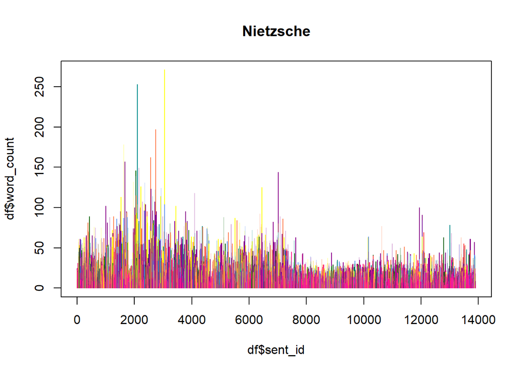

```r
nietzsche_data <- get_author(phi_data,"Nietzsche")
senti_plot(nietzsche_data,"Nietzsche")
```

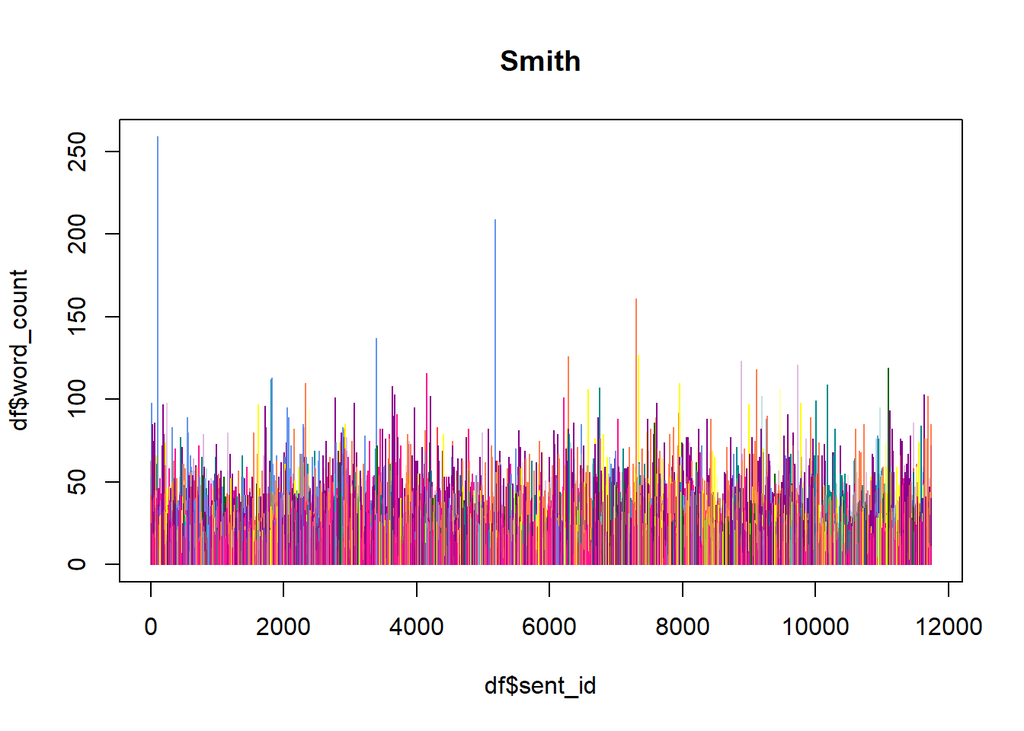

```r
 smith_data <- get_author(phi_data,"Smith")
senti_plot(smith_data,"Smith")
```